# Understanding Startup Descriptions with Topic Modeling

Kent Gang  
December 27, 2019

#### Contents

1. Introduction
2. Data Intake  
   2.1. Data Cleaning  
   2.2. Removing Stop Words  
   2.3. NLP Preprocessing  
   2.4. Bigrams and Trigrams
3. Topic Modeling with Latent Dirichlet Allocation  
   3.1. Model Tuning
4. Model Interpretation
5. Application  
   5.1. Next Steps

## 1.0 Introduction

Crunchbase is an aggregator of information related to startups, including descriptions of their business, founder bios, and funding events. We'll be using the [Crunchbase 2013 Snapshot](https://data.crunchbase.com/docs/2013-snapshot) to analyze the long descriptions of the companies using NLP and topic modeling. We'll see what classifications exists within software startups and if that information can be used to new companies.

The dataset is available through a free Crunchbase Data account [here](https://data.crunchbase.com/docs/2013-snapshot) and represents historical Crunchbase data collected before December 2013. It is licensed under Creative Commons with Attribution [CC-BY](https://creativecommons.org/licenses/by/4.0/). © 2013

All content and files can be found on my repo here.

## 2.0 Data Intake

See the README for setting up the MySQL database, if starting from scratch. Once you're ready, we'll load the company descriptions into a pandas DataFrame. Skip down to Data Cleaning - Removing Stop Words to avoid database setup and use included pickle files.

```python
import getpass, pprint
import pandas as pd
import sqlalchemy as sql
```

```python
pw = getpass.getpass()
connect_string = 'mysql://root:{pw}@localhost/crunchdb?charset=utf8mb4'.format(pw=pw)
sql_engine = sql.create_engine(connect_string)
del pw, connect_string
```

```python
tables = pd.read_sql_query("show tables;", sql_engine)
tables
```

|  | Tables_in_crunchdb |
| --- | --- |
| 0 | cb_acquisitions |
| 1 | cb_degrees |
| 2 | cb_funding_rounds |
| 3 | cb_funds |
| 4 | cb_investments |
| 5 | cb_ipos |
| 6 | cb_milestones |
| 7 | cb_objects |
| 8 | cb_offices |
| 9 | cb_people |
| 10 | cb_relationships |

```python
cb_objects = pd.read_sql_query("select * from cb_objects",
                              sql_engine)
print(cb_objects.shape)
cb_objects.head()
```

```
(462651, 40)
```

|  | id | entity_type | entity_id | parent_id | name | normalized_name | permalink | category_code | status | founded_at | ... | last_funding_at | funding_rounds | funding_total_usd | first_milestone_at | last_milestone_at | milestones | relationships | created_by | created_at | updated_at |
| --- | --- | --- | --- | --- | --- | --- | --- | --- | --- | --- | --- | --- | --- | --- | --- | --- | --- | --- | --- | --- | --- |
| 0 | c:1 | Company | 1 | None | Wetpaint | wetpaint | /company/wetpaint | web | operating | 2005-10-17 | ... | 2008-05-19 | 3.0 | 39750000.0 | 2010-09-05 | 2013-09-18 | 5.0 | 17.0 | initial-importer | 2007-05-25 06:51:27 | 2013-04-13 03:29:00 |
| 1 | c:10 | Company | 10 | None | Flektor | flektor | /company/flektor | games_video | acquired | None | ... | None | NaN | NaN | None | None | NaN | 6.0 | initial-importer | 2007-05-31 21:11:51 | 2008-05-23 23:23:14 |
| 2 | c:100 | Company | 100 | None | There | there | /company/there | games_video | acquired | None | ... | None | NaN | NaN | 2003-02-01 | 2011-09-23 | 4.0 | 12.0 | initial-importer | 2007-08-06 23:52:45 | 2013-11-04 02:09:48 |
| 3 | c:10000 | Company | 10000 | None | MYWEBBO | mywebbo | /company/mywebbo | network_hosting | operating | 2008-07-26 | ... | None | NaN | NaN | None | None | NaN | NaN | None | 2008-08-24 16:51:57 | 2008-09-06 14:19:18 |
| 4 | c:10001 | Company | 10001 | None | THE Movie Streamer | the movie streamer | /company/the-movie-streamer | games_video | operating | 2008-07-26 | ... | None | NaN | NaN | None | None | NaN | NaN | None | 2008-08-24 17:10:34 | 2008-09-06 14:19:18 |

5 rows × 40 columns

```python
print(cb_objects.iloc[0].to_string())
```

```
id                                                                   c:1
entity_type                                                      Company
entity_id                                                              1
parent_id                                                           None
name                                                            Wetpaint
normalized_name                                                 wetpaint
permalink                                              /company/wetpaint
category_code                                                        web
status                                                         operating
founded_at                                                    2005-10-17
closed_at                                                           None
domain                                                  wetpaint-inc.com
homepage_url                                     http://wetpaint-inc.com
twitter_username                                         BachelrWetpaint
logo_url               http://s3.amazonaws.com/crunchbase_prod_assets...
logo_width                                                           401
logo_height                                                           54
short_description                                                   None
description                                  Technology Platform Company
overview               Wetpaint is a technology platform company that...
tag_list               wiki, seattle, elowitz, media-industry, media-...
country_code                                                         USA
state_code                                                            WA
city                                                             Seattle
region                                                           Seattle
first_investment_at                                                 None
last_investment_at                                                  None
investment_rounds                                                    NaN
invested_companies                                                   NaN
first_funding_at                                              2005-10-01
last_funding_at                                               2008-05-19
funding_rounds                                                         3
funding_total_usd                                              3.975e+07
first_milestone_at                                            2010-09-05
last_milestone_at                                             2013-09-18
milestones                                                             5
relationships                                                         17
created_by                                              initial-importer
created_at                                           2007-05-25 06:51:27
updated_at                                           2013-04-13 03:29:00
```

```python
from pprint import pprint
```

```python
with pd.option_context('display.max_rows', None,
                       'display.max_columns', None,
                       'display.max_colwidth', -1):  # more options can be specified also
    print(cb_objects[0:5])
```

```
        id entity_type  entity_id parent_id                name  \
0  c:1      Company     1          None      Wetpaint
1  c:10     Company     10         None      Flektor
2  c:100    Company     100        None      There
3  c:10000  Company     10000      None      MYWEBBO
4  c:10001  Company     10001      None      THE Movie Streamer

      normalized_name                    permalink    category_code  \
0  wetpaint            /company/wetpaint            web
1  flektor             /company/flektor             games_video
2  there               /company/there               games_video
3  mywebbo             /company/mywebbo             network_hosting
4  the movie streamer  /company/the-movie-streamer  games_video

      status  founded_at closed_at                domain  \
```

[output cut: 75 more lines]

```python
cb_objects['category_code'].value_counts()
```

```
software            17922
web                 15118
other               13617
ecommerce            9065
games_video          7520
mobile               6862
advertising          6098
consulting           5006
enterprise           4441
biotech              4430
hardware             2951
education            2901
public_relations     2846
network_hosting      2350
search               2182
cleantech            1940
health               1698
finance              1386
social               1310
security             1171
medical              1153
analytics            1022
legal                1012
travel                936
local                 785
news                  768
hospitality           768
semiconductor         696
manufacturing         680
sports                675
music                 581
fashion               563
photo_video           544
transportation        489
real_estate           474
messaging             296
automotive            291
design                281
nonprofit             184
nanotech               70
pets                   61
government             43
Name: category_code, dtype: int64
```

```python
# Let's narrow down our analysis to software startups

df = cb_objects.loc[cb_objects.category_code == 'software',]
```

```python
df.loc[:,('founded_at')] = pd.to_datetime(df.founded_at, errors='coerce')
```

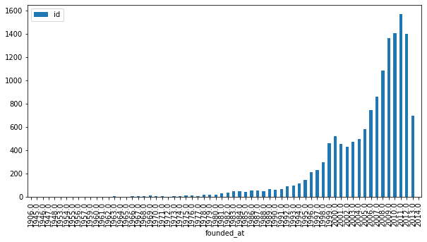

```python
%matplotlib inline
df.groupby(df.founded_at.dt.year).agg({'id':'count'}).plot(kind='bar',figsize=(10,5))
```

```python
# Obviously a mistake, this datasset is a snapshot from 2013
df.loc[df.founded_at.dt.year == 2014,]
```

|  | id | entity_type | entity_id | parent_id | name | normalized_name | permalink | category_code | status | founded_at | ... | last_funding_at | funding_rounds | funding_total_usd | first_milestone_at | last_milestone_at | milestones | relationships | created_by | created_at | updated_at |
| --- | --- | --- | --- | --- | --- | --- | --- | --- | --- | --- | --- | --- | --- | --- | --- | --- | --- | --- | --- | --- | --- |
| 99795 | c:244731 | Company | 244731 | None | raavel | raavel | /company/raavel | software | operating | 2014-08-01 | ... | None | NaN | NaN | None | None | NaN | NaN | mxpatel29 | 2013-08-04 22:02:15 | 2013-08-23 16:29:41 |

1 rows × 40 columns

```python
# Let's filter down the dataset some more to just those founded between the years 2000-2008

df = df.loc[(df.founded_at.dt.year >= 2000)&(df.founded_at.dt.year <=2008),]
df.groupby(df.founded_at.dt.year).agg({'id':'count'})
```

| founded_at | id |
| --- | --- |
| 2000 | 523 |
| 2001 | 455 |
| 2002 | 427 |
| 2003 | 474 |
| 2004 | 497 |
| 2005 | 579 |
| 2006 | 748 |
| 2007 | 858 |
| 2008 | 1087 |

```python
df.shape
```

```
(5648, 40)
```

```python
df.isnull().sum()
```

```
id                        0
entity_type               0
entity_id                 0
parent_id              5648
name                      0
normalized_name           0
permalink                 0
category_code             0
status                    0
founded_at                0
closed_at              5506
domain                  148
homepage_url            148
twitter_username       1931
logo_url                545
logo_width              545
logo_height             545
short_description      5355
description             401
overview                 29
tag_list                205
country_code            874
state_code             3049
city                    958
region                    0
first_investment_at    5618
last_investment_at     5618
investment_rounds      5618
invested_companies     5618
first_funding_at       3933
last_funding_at        3933
funding_rounds         3916
funding_total_usd      4023
first_milestone_at     3038
last_milestone_at      3038
milestones             3038
relationships          1831
created_by             2424
created_at                0
updated_at                0
dtype: int64
```

```python
# Since we'll be using the overview field for our analysis, remove those observations that are null

df = df.loc[~df.overview.isnull(),]
df.shape
```

```
(5619, 40)
```

```python
# Keep just the normalized_name, overview, tag_list, and funding_total_usd columns
df = df.loc[:,('normalized_name','overview','tag_list','funding_total_usd')]
df.shape
```

```
(5619, 4)
```

```python
df.head()
```

|  | normalized_name | overview | tag_list | funding_total_usd |
| --- | --- | --- | --- | --- |
| 60 | oms safeharbor | OMS SafeHarbor provides software and services ... | software-distribution, electronic-software-del... | NaN |
| 65 | datapro services internationalltd | Datapro Services International Co, Ltd based i... | rss, bangkok, thailand, magazine | NaN |
| 121 | epianalytics | EpiAnalytics provides easy-to-use text and sen... | twitter-sentiment-analysis, nlp, epianalytics,... | NaN |
| 122 | amax global services | AMAX Global Services (AGS) is a software devel... |  | 45000.0 |
| 130 | tingz | Tingz is changing the way people experience th... | techcrunch50, tc50, consumer, software, widgets | 280000.0 |

```python
# Let's fill the missing funding values in with zeroes
df['funding_total_usd'] = df.funding_total_usd.fillna(0)
df.head()
```

|  | normalized_name | overview | tag_list | funding_total_usd |
| --- | --- | --- | --- | --- |
| 60 | oms safeharbor | OMS SafeHarbor provides software and services ... | software-distribution, electronic-software-del... | 0.0 |
| 65 | datapro services internationalltd | Datapro Services International Co, Ltd based i... | rss, bangkok, thailand, magazine | 0.0 |
| 121 | epianalytics | EpiAnalytics provides easy-to-use text and sen... | twitter-sentiment-analysis, nlp, epianalytics,... | 0.0 |
| 122 | amax global services | AMAX Global Services (AGS) is a software devel... |  | 45000.0 |
| 130 | tingz | Tingz is changing the way people experience th... | techcrunch50, tc50, consumer, software, widgets | 280000.0 |

```python
# Add the tag_list to the overview for some extra information
df['overview'] = df['overview'] + ' ' + df['tag_list'].fillna('')
```

###### Go to top

## 2.1 Data Cleaning

Now we're ready to clean the data!

```python
for i in range(10):
    pprint(df.iloc[i][['normalized_name','overview']].values)
```

```
array(['oms safeharbor',
       'OMS SafeHarbor provides software and services to enable the electronic delivery of software and software licenses. software-distribution, electronic-software-delivery, esd, license-management, software-downloads, export-compliance'],
      dtype=object)
array(['datapro services internationalltd',
       'Datapro Services International Co, Ltd based in Bangkok, Thailand manage several online properties including FeedZa, Juice Mag and a web development center. rss, bangkok, thailand, magazine'],
      dtype=object)
array(['epianalytics',
       "EpiAnalytics provides easy-to-use text and sentiment analysis so companies can actively reduce costs, gain consumer insight, make better customer-focused decisions and automate response to customer service requests and survey comments.\r\n\r\nEpiAnalytics solution suite consists of three mai…
      dtype=object)
array(['amax global services',
       'AMAX Global Services (AGS) is a software development and offshore outsourcing business partner that is headquartered in Fremont, California and leverages its Offshore Development Centers strategically located in Shanghai and Suzhou, China. \r\n\r\nWe are dedicated to providing value added se…
      dtype=object)
array(['tingz',
       'Tingz is changing the way people experience the Internet by giving them tools and services to gather content from across the web and distribute it directly to their digital devices and social networks. Tingz offers a surprisingly consistent and easy experience across a wide variety of device…
      dtype=object)
array(['spotmau',
       "Spotmau.com is a provider of leading software utilities products designed for configuring, optimizing and repairing computer systems. The products' powerfulness and low prices benefit many computer users in the home, SoHo and Business markets. utilites-software"],
      dtype=object)
array(['galaxy',
       "Galaxy is an online collaborative work environment that connects people and projects around the world. \r\n\r\nGalaxy features a unique dashboard that allows managers to see every group, user, and project from one screen. Users get up and running fast, allowing managers the ability to quickl…
      dtype=object)
array(['elemental learning',
       'Elemental Learning applies new and emerging technologies to the training process to make it more effective and efficient.\r\n\r\nWhile doing this, they created LearningLinx - a revolutionary skills and content development platform built from the ground-up to help schools, universities and co…
      dtype=object)
array(['producteev',
       'Producteev is one of the leading free Task Management applications for Individuals and Teams connected to : Mac (Mac App Store), Windows Desktop, Web, iPhone, Android, IM (Gtalk, AIM, Yahoo Messenger...), EMail (send tasks to task@producteev.com), Gmail, GCal...\r\n basecamp, project-managem…
      dtype=object)
array(['contrust',
       'ConTrust ("Content you can trust") offers a technologically advanced and cohesive SaaS (Software as a Service) solution that enables you to moderate your content in real-time according to your platform values. \r\n\r\nAs a media platform you need to moderate the level of noise according to t…
      dtype=object)
```

```python
import re

def clean_text(text):
    """Removes emails, urls, text in parentheses, and \r or \n.
       Replace dashes in words with spaces(e.g. easy-to-use > easy to use)"""
    text = re.sub('\S*@\S*\s?', '', text)
    text = re.sub('\S*\.\S+','',text)
    text = re.sub('\(.*?\)','', text)
    text = re.sub('\\n|\\r','',text)
    text = re.sub('(?<=\S)-',' ', text)
    return text
```

```python
df['overview'] = df['overview'].apply(clean_text)
for i in range(10):
    pprint(df.iloc[i][['normalized_name','overview']].values)
```

```
array(['oms safeharbor',
       'OMS SafeHarbor provides software and services to enable the electronic delivery of software and software licenses. software distribution, electronic software delivery, esd, license management, software downloads, export compliance'],
      dtype=object)
array(['datapro services internationalltd',
       'Datapro Services International Co, Ltd based in Bangkok, Thailand manage several online properties including FeedZa, Juice Mag and a web development center. rss, bangkok, thailand, magazine'],
      dtype=object)
array(['epianalytics',
       "EpiAnalytics provides easy to use text and sentiment analysis so companies can actively reduce costs, gain consumer insight, make better customer focused decisions and automate response to customer service requests and survey comments.EpiAnalytics solution suite consists of three main offeri…
      dtype=object)
array(['amax global services',
       'AMAX Global Services  is a software development and offshore outsourcing business partner that is headquartered in Fremont, California and leverages its Offshore Development Centers strategically located in Shanghai and Suzhou, China. We are dedicated to providing value added services with h…
      dtype=object)
array(['tingz',
       'Tingz is changing the way people experience the Internet by giving them tools and services to gather content from across the web and distribute it directly to their digital devices and social networks. Tingz offers a surprisingly consistent and easy experience across a wide variety of device…
      dtype=object)
array(['spotmau',
       " is a provider of leading software utilities products designed for configuring, optimizing and repairing computer systems. The products' powerfulness and low prices benefit many computer users in the home, SoHo and Business markets. utilites software"],
      dtype=object)
array(['galaxy',
       "Galaxy is an online collaborative work environment that connects people and projects around the world. Galaxy features a unique dashboard that allows managers to see every group, user, and project from one screen. Users get up and running fast, allowing managers the ability to quickly create…
      dtype=object)
array(['elemental learning',
       'Elemental Learning applies new and emerging technologies to the training process to make it more effective and efficient.While doing this, they created LearningLinx - a revolutionary skills and content development platform built from the ground up to help schools, universities and corporatio…
      dtype=object)
array(['producteev',
       'Producteev is one of the leading free Task Management applications for Individuals and Teams connected to : Mac , Windows Desktop, Web, iPhone, Android, IM (Gtalk, AIM, Yahoo  EMail (send tasks to Gmail,  basecamp, project management, productivity, task management, collaboration, project man…
      dtype=object)
array(['contrust',
       "ConTrust  offers a technologically advanced and cohesive SaaS  solution that enables you to moderate your content in real time according to your platform values. As a media platform you need to moderate the level of noise according to the values of your community. This is not an easy challen…
      dtype=object)
```

```python
# Save this since it's been transformed to avoid licensing issues
df.to_pickle("pickle/clean_df.pkl")
```

###### Go to top

## 2.2 Removing Stop Words

Let's see what the most common words are in the reviews and remove them. First step is to create a document term matrix with a count vectorizer.

```python
import pandas as pd
from sklearn.feature_extraction import text
from sklearn.feature_extraction.text import CountVectorizer
```

```python
clean_df = pd.read_pickle('pickle/clean_df.pkl')
```

```python
clean_overviews = clean_df[['normalized_name','overview']].set_index('normalized_name')
clean_overviews.head()
```

| normalized_name | overview |
| --- | --- |
| oms safeharbor | OMS SafeHarbor provides software and services ... |
| datapro services internationalltd | Datapro Services International Co, Ltd based i... |
| epianalytics | EpiAnalytics provides easy to use text and sen... |
| amax global services | AMAX Global Services is a software developmen... |
| tingz | Tingz is changing the way people experience th... |

```python
cv = CountVectorizer(stop_words='english')
crunch_cv = cv.fit_transform(clean_overviews.overview)
overview_dtm = pd.DataFrame(crunch_cv.toarray(), columns=cv.get_feature_names())
overview_dtm.index = clean_overviews.index
overview_dtm
```

| normalized_name | 00 | 000 | 000th | 001 | 00500 | 0092321 | 01 | 0120 | 013netvision | 02e | ... | zurich | zusammenarbeit | zusätzlich | zvision | zvoice | zwcad | zyl | zyrion | zürich | über |
| --- | --- | --- | --- | --- | --- | --- | --- | --- | --- | --- | --- | --- | --- | --- | --- | --- | --- | --- | --- | --- | --- |
| oms safeharbor | 0 | 0 | 0 | 0 | 0 | 0 | 0 | 0 | 0 | 0 | ... | 0 | 0 | 0 | 0 | 0 | 0 | 0 | 0 | 0 | 0 |
| datapro services internationalltd | 0 | 0 | 0 | 0 | 0 | 0 | 0 | 0 | 0 | 0 | ... | 0 | 0 | 0 | 0 | 0 | 0 | 0 | 0 | 0 | 0 |
| epianalytics | 0 | 0 | 0 | 0 | 0 | 0 | 0 | 0 | 0 | 0 | ... | 0 | 0 | 0 | 0 | 0 | 0 | 0 | 0 | 0 | 0 |
| amax global services | 0 | 0 | 0 | 0 | 0 | 0 | 0 | 0 | 0 | 0 | ... | 0 | 0 | 0 | 0 | 0 | 0 | 0 | 0 | 0 | 0 |
| tingz | 0 | 0 | 0 | 0 | 0 | 0 | 0 | 0 | 0 | 0 | ... | 0 | 0 | 0 | 0 | 0 | 0 | 0 | 0 | 0 | 0 |
| ... | ... | ... | ... | ... | ... | ... | ... | ... | ... | ... | ... | ... | ... | ... | ... | ... | ... | ... | ... | ... | ... |
| myouvies | 0 | 0 | 0 | 0 | 0 | 0 | 0 | 0 | 0 | 0 | ... | 0 | 0 | 0 | 0 | 0 | 0 | 0 | 0 | 0 | 0 |
| hyva it solutions | 0 | 0 | 0 | 0 | 0 | 0 | 0 | 0 | 0 | 0 | ... | 0 | 0 | 0 | 0 | 0 | 0 | 0 | 0 | 0 | 0 |
| lyft | 0 | 0 | 0 | 0 | 0 | 0 | 0 | 0 | 0 | 0 | ... | 0 | 0 | 0 | 0 | 0 | 0 | 0 | 0 | 0 | 0 |
| connective logic | 0 | 0 | 0 | 0 | 0 | 0 | 0 | 0 | 0 | 0 | ... | 0 | 0 | 0 | 0 | 0 | 0 | 0 | 0 | 0 | 0 |
| atandra | 0 | 0 | 0 | 0 | 0 | 0 | 0 | 0 | 0 | 0 | ... | 0 | 0 | 0 | 0 | 0 | 0 | 0 | 0 | 0 | 0 |

5619 rows × 27207 columns

```python
# Let's get rid of the numbers and words with numbers
import re
def clean_text_ofnum(text):
    text = re.sub('\S*[0-9]+\S*', '', text)
    return text

clean_overviews['overview'] = clean_overviews['overview'].apply(clean_text_ofnum)
```

```python
crunch_cv = cv.fit_transform(clean_overviews.overview)
overview_dtm = pd.DataFrame(crunch_cv.toarray(), columns=cv.get_feature_names())
overview_dtm.index = clean_overviews.index
overview_dtm
```

| normalized_name | _____________________________________________how | _____________________________________________why | _a | _blank | _conversion | _pro | _project | _select | _split | _stickystreet_ | ... | zurich | zusammenarbeit | zusätzlich | zvision | zvoice | zwcad | zyl | zyrion | zürich | über |
| --- | --- | --- | --- | --- | --- | --- | --- | --- | --- | --- | --- | --- | --- | --- | --- | --- | --- | --- | --- | --- | --- |
| oms safeharbor | 0 | 0 | 0 | 0 | 0 | 0 | 0 | 0 | 0 | 0 | ... | 0 | 0 | 0 | 0 | 0 | 0 | 0 | 0 | 0 | 0 |
| datapro services internationalltd | 0 | 0 | 0 | 0 | 0 | 0 | 0 | 0 | 0 | 0 | ... | 0 | 0 | 0 | 0 | 0 | 0 | 0 | 0 | 0 | 0 |
| epianalytics | 0 | 0 | 0 | 0 | 0 | 0 | 0 | 0 | 0 | 0 | ... | 0 | 0 | 0 | 0 | 0 | 0 | 0 | 0 | 0 | 0 |
| amax global services | 0 | 0 | 0 | 0 | 0 | 0 | 0 | 0 | 0 | 0 | ... | 0 | 0 | 0 | 0 | 0 | 0 | 0 | 0 | 0 | 0 |
| tingz | 0 | 0 | 0 | 0 | 0 | 0 | 0 | 0 | 0 | 0 | ... | 0 | 0 | 0 | 0 | 0 | 0 | 0 | 0 | 0 | 0 |
| ... | ... | ... | ... | ... | ... | ... | ... | ... | ... | ... | ... | ... | ... | ... | ... | ... | ... | ... | ... | ... | ... |
| myouvies | 0 | 0 | 0 | 0 | 0 | 0 | 0 | 0 | 0 | 0 | ... | 0 | 0 | 0 | 0 | 0 | 0 | 0 | 0 | 0 | 0 |
| hyva it solutions | 0 | 0 | 0 | 0 | 0 | 0 | 0 | 0 | 0 | 0 | ... | 0 | 0 | 0 | 0 | 0 | 0 | 0 | 0 | 0 | 0 |
| lyft | 0 | 0 | 0 | 0 | 0 | 0 | 0 | 0 | 0 | 0 | ... | 0 | 0 | 0 | 0 | 0 | 0 | 0 | 0 | 0 | 0 |
| connective logic | 0 | 0 | 0 | 0 | 0 | 0 | 0 | 0 | 0 | 0 | ... | 0 | 0 | 0 | 0 | 0 | 0 | 0 | 0 | 0 | 0 |
| atandra | 0 | 0 | 0 | 0 | 0 | 0 | 0 | 0 | 0 | 0 | ... | 0 | 0 | 0 | 0 | 0 | 0 | 0 | 0 | 0 | 0 |

5619 rows × 26078 columns

```python
# Also remove words that start with punctuation
def clean_text_ofpunct(text):
    text = re.sub('[_\-\'\"]+\S+', '', text)
    return text

clean_overviews['overview'] = clean_overviews['overview'].apply(clean_text_ofpunct)
crunch_cv = cv.fit_transform(clean_overviews.overview)
overview_dtm = pd.DataFrame(crunch_cv.toarray(), columns=cv.get_feature_names())
overview_dtm.index = clean_overviews.index
overview_dtm
```

| normalized_name | aaa | aac | aace | aahlad | aalpha | aaron | aayan | ab | aba | abacus | ... | zurich | zusammenarbeit | zusätzlich | zvision | zvoice | zwcad | zyl | zyrion | zürich | über |
| --- | --- | --- | --- | --- | --- | --- | --- | --- | --- | --- | --- | --- | --- | --- | --- | --- | --- | --- | --- | --- | --- |
| oms safeharbor | 0 | 0 | 0 | 0 | 0 | 0 | 0 | 0 | 0 | 0 | ... | 0 | 0 | 0 | 0 | 0 | 0 | 0 | 0 | 0 | 0 |
| datapro services internationalltd | 0 | 0 | 0 | 0 | 0 | 0 | 0 | 0 | 0 | 0 | ... | 0 | 0 | 0 | 0 | 0 | 0 | 0 | 0 | 0 | 0 |
| epianalytics | 0 | 0 | 0 | 0 | 0 | 0 | 0 | 0 | 0 | 0 | ... | 0 | 0 | 0 | 0 | 0 | 0 | 0 | 0 | 0 | 0 |
| amax global services | 0 | 0 | 0 | 0 | 0 | 0 | 0 | 0 | 0 | 0 | ... | 0 | 0 | 0 | 0 | 0 | 0 | 0 | 0 | 0 | 0 |
| tingz | 0 | 0 | 0 | 0 | 0 | 0 | 0 | 0 | 0 | 0 | ... | 0 | 0 | 0 | 0 | 0 | 0 | 0 | 0 | 0 | 0 |
| ... | ... | ... | ... | ... | ... | ... | ... | ... | ... | ... | ... | ... | ... | ... | ... | ... | ... | ... | ... | ... | ... |
| myouvies | 0 | 0 | 0 | 0 | 0 | 0 | 0 | 0 | 0 | 0 | ... | 0 | 0 | 0 | 0 | 0 | 0 | 0 | 0 | 0 | 0 |
| hyva it solutions | 0 | 0 | 0 | 0 | 0 | 0 | 0 | 0 | 0 | 0 | ... | 0 | 0 | 0 | 0 | 0 | 0 | 0 | 0 | 0 | 0 |
| lyft | 0 | 0 | 0 | 0 | 0 | 0 | 0 | 0 | 0 | 0 | ... | 0 | 0 | 0 | 0 | 0 | 0 | 0 | 0 | 0 | 0 |
| connective logic | 0 | 0 | 0 | 0 | 0 | 0 | 0 | 0 | 0 | 0 | ... | 0 | 0 | 0 | 0 | 0 | 0 | 0 | 0 | 0 | 0 |
| atandra | 0 | 0 | 0 | 0 | 0 | 0 | 0 | 0 | 0 | 0 | ... | 0 | 0 | 0 | 0 | 0 | 0 | 0 | 0 | 0 | 0 |

5619 rows × 26009 columns

```python
# Let's see if we can determine more stop words by looking at the most frequently used
overview_dtm.sum().sort_values(ascending=False)[:50]
```

```
software        8310
development     4655
web             4618
company         4179
management      4154
solutions       3767
services        3388
business        2975
based           2757
mobile          2391
data            2349
provides        2132
technology      2066
applications    2035
application     1863
service         1854
online          1848
design          1688
platform        1532
products        1478
time            1456
solution        1419
marketing       1393
companies       1345
information     1285
customers       1276
social          1267
founded         1256
systems         1254
offers          1247
product         1209
content         1195
enterprise      1176
clients         1120
customer        1116
media           1087
users           1052
cloud           1045
support         1030
new             1005
website          993
video            966
technologies     962
use              942
industry         881
network          863
tools            856
internet         847
team             833
world            825
dtype: int64
```

```python
# These first 9 probably don't give any additional information knowing their software companies
software_stops = list(overview_dtm.sum().sort_values(ascending=False)[:9].index)
software_stops
```

```
['software',
 'development',
 'web',
 'company',
 'management',
 'solutions',
 'services',
 'business',
 'based']
```

###### Go to top

## 2.3 NLP Pre-processing

SpaCy will help now with lemmatizing (converting words to their root form), tokenizing (identifying parts of speech and punctuation), and entity detection.

```python
# Run the following in terminal or
# with ! to run through Jupyter as magic
! python -m spacy download en_core_web_sm
import spacy
from spacy.lemmatizer import Lemmatizer
from spacy.lang.en.stop_words import STOP_WORDS
nlp = spacy.load("en_core_web_sm")
```

```
✔ Download and installation successful
You can now load the model via spacy.load('en_core_web_sm')
```

```python
# Update default stop words set and adjust their property
# Also add some company suffixes
nlp.Defaults.stop_words.update(software_stops + ['co','ltd','etc','inc','llc','llp'])
for word in STOP_WORDS:
    st = nlp.vocab[word]
    st.is_stop = True
```

```python
def space_or_punct(token):
    """Helper function to identify space and punctuation."""
    return token.is_punct or token.is_space

def pronoun_or_person(token):
    """Helper function to identify pronouns and people."""
    return (token.lemma_ == '-PRON-') or (token.ent_type_ == 'PERSON')

def lemmatizer(overview):
    """Lemmatizes and removes punctuation and people."""
    overview = [token.lemma_ for token in overview
                if not space_or_punct(token) and not pronoun_or_person(token)]
    doc = u' '.join(overview)
    return nlp.make_doc(doc)

def remove_stopwords(overview):
    """Returns text for modeling."""
    overview = [token.text.lower() for token in overview if not token.is_stop]
    return overview

nlp.add_pipe(lemmatizer, name='lemmatizer', after='ner')
nlp.add_pipe(remove_stopwords, name='rm_stopwords', last=True)
```

```python
def preprocess_overview(text_set):
    processed = []
    for text in text_set:
        processed.append(nlp(text))
    return processed
```

```python
# %%time
# #Takes awhile -- Uncomment to run yourself
# #Pickled result included
#
# preprocessed_overview = preprocess_overview(clean_overviews.overview)
# for i in range(3):
#     print('original: \n')
#     print(clean_overviews.overview[i])
#     print('processed: \n')
#     print(preprocessed_overview[i])
# preprocessed_df = clean_df.copy()
# preprocessed_df['preprocessed_overview'] = processed_overview
# preprocessed_df.to_pickle("pickle/preprocessed_df.pkl")
```

###### Go to top

## 2.4 Bigrams and Trigrams

Next is using gensim to model n-grams, or meaningful combinations of words.

```python
from gensim.models import Phrases
from gensim.models.word2vec import LineSentence
```

```python
pdf = pd.read_pickle('pickle/preprocessed_df.pkl')
```

```python
# %%time
#
# bigram_model = Phrases(pdf.processed_overview)
# bigram_model.save("models/bigram_model")
```

```
CPU times: user 1.17 s, sys: 137 ms, total: 1.31 s
Wall time: 1.35 s
```

```python
bigram_model = Phrases.load("models/bigram_model")
bigram_overview_list = []
for overview in pdf.preprocessed_overview:
    bigram_overview_list.append(bigram_model[overview])
```

```python
# We can see that the bigrams detected make intuitive sense
for overview in bigram_overview_list[0:10]:
    for word in overview:
        if '_' in word:
            print(word)
```

```
easy_use
sentiment_analysis
reduce_cost
contact_center
process_automation
customer_feedback
real_time
text_analytic
social_media
contact_center
lower_cost
sentiment_analysis
contact_center
offshore_outsourcing
fremont_california
value_add
highly_qualified
startup_fortune
value_add
high_quality
intellectual_property
change_way
social_network
wide_variety
operating_system
seamlessly_integrate
low_price
connect_people
remote_access
emerge_technology
build_ground
training_education
corporate_training
iphone_android
real_time
find_right
user_friendly
significantly_reduce
brand_reputation
```

```python
# %%time
#
# trigram_model = Phrases(bigram_overview_list)
# trigram_model.save("models/trigram_model")
```

```python
trigram_model = Phrases.load("models/trigram_model")
trigram_overview_list = []
for overview in bigram_overview_list:
    trigram_overview_list.append(trigram_model[overview])
```

```python
for overview in trigram_overview_list[0:100]:
    for word in overview:
        if word.count('_') == 2:
            print(word)
```

```
value_add_service
value_add_service
change_way_people
rich_internet_application
provide_high_quality
social_networking_site
palo_alto_california
manage_file_transfer
large_file_transfer
manage_file_transfer
secure_file_transfer
search_engine_optimization
small_medium_size
custom_website_design
deliver_high_quality
small_medium_sized
microsoft_dynamics_crm
change_way_people
california_additional_office
manage_file_transfer
manage_file_transfer
improve_operational_efficiency
rich_internet_application
real_time_visibility
social_medium_marketing
iphone_ipad_android
natural_language_processing
industry_found_base
office_new_york
testing_quality_assurance
virtual_data_room
virtual_data_room
end_end_solution
```

```python
ngrammed_df = pdf.copy()
ngrammed_df ['bigrammed_overview'] = bigram_overview_list
ngrammed_df ['trigrammed_overview'] = trigram_overview_list
ngrammed_df.to_pickle('pickle/ngrammed_df.pkl')
ngrammed_df.head()
```

|  | normalized_name | overview | tag_list | funding_total_usd | processed_overview | preprocessed_overview | bigrammed_overview | trigrammed_overview |
| --- | --- | --- | --- | --- | --- | --- | --- | --- |
| 60 | oms safeharbor | OMS SafeHarbor provides software and services ... | software-distribution, electronic-software-del... | 0.0 | [provide, service, enable, electronic, deliver... | [provide, service, enable, electronic, deliver... | [provide, service, enable, electronic, deliver... | [provide, service, enable, electronic, deliver... |
| 65 | datapro services internationalltd | Datapro Services International Co, Ltd based i... | rss, bangkok, thailand, magazine | 0.0 | [datapro, international, co, ltd, base, bangko... | [datapro, international, co, ltd, base, bangko... | [datapro, international, co, ltd, base, bangko... | [datapro, international, co, ltd, base, bangko... |
| 121 | epianalytics | EpiAnalytics provides easy to use text and sen... | twitter-sentiment-analysis, nlp, epianalytics,... | 0.0 | [epianalytic, provide, easy, use, text, sentim... | [epianalytic, provide, easy, use, text, sentim... | [epianalytic, provide, easy_use, text, sentime... | [epianalytic, provide, easy_use, text, sentime... |
| 122 | amax global services | AMAX Global Services is a software developmen... |  | 45000.0 | [amax, global, offshore, outsourcing, partner,... | [amax, global, offshore, outsourcing, partner,... | [amax, global, offshore_outsourcing, partner, ... | [amax, global, offshore_outsourcing, partner, ... |
| 130 | tingz | Tingz is changing the way people experience th... | techcrunch50, tc50, consumer, software, widgets | 280000.0 | [change, way, people, experience, internet, to... | [change, way, people, experience, internet, to... | [change_way, people, experience, internet, too... | [change_way_people, experience, internet, tool... |

###### Go to top

## 3.0 Topic Modeling with Latent Dirichlet Allocation (LDA)

The data is finally ready for topic modeling.

```python
ndf = pd.read_pickle('pickle/ngrammed_df.pkl')
ndf.head()
```

|  | normalized_name | overview | tag_list | funding_total_usd | processed_overview | preprocessed_overview | bigrammed_overview | trigrammed_overview |
| --- | --- | --- | --- | --- | --- | --- | --- | --- |
| 60 | oms safeharbor | OMS SafeHarbor provides software and services ... | software-distribution, electronic-software-del... | 0.0 | [provide, service, enable, electronic, deliver... | [provide, service, enable, electronic, deliver... | [provide, service, enable, electronic, deliver... | [provide, service, enable, electronic, deliver... |
| 65 | datapro services internationalltd | Datapro Services International Co, Ltd based i... | rss, bangkok, thailand, magazine | 0.0 | [datapro, international, co, ltd, base, bangko... | [datapro, international, co, ltd, base, bangko... | [datapro, international, co, ltd, base, bangko... | [datapro, international, co, ltd, base, bangko... |
| 121 | epianalytics | EpiAnalytics provides easy to use text and sen... | twitter-sentiment-analysis, nlp, epianalytics,... | 0.0 | [epianalytic, provide, easy, use, text, sentim... | [epianalytic, provide, easy, use, text, sentim... | [epianalytic, provide, easy_use, text, sentime... | [epianalytic, provide, easy_use, text, sentime... |
| 122 | amax global services | AMAX Global Services is a software developmen... |  | 45000.0 | [amax, global, offshore, outsourcing, partner,... | [amax, global, offshore, outsourcing, partner,... | [amax, global, offshore_outsourcing, partner, ... | [amax, global, offshore_outsourcing, partner, ... |
| 130 | tingz | Tingz is changing the way people experience th... | techcrunch50, tc50, consumer, software, widgets | 280000.0 | [change, way, people, experience, internet, to... | [change, way, people, experience, internet, to... | [change_way, people, experience, internet, too... | [change_way_people, experience, internet, tool... |

```python
from gensim.corpora import Dictionary, MmCorpus
from gensim.models import LdaModel, CoherenceModel

import pyLDAvis
import pyLDAvis.gensim
import pickle
```

```python
# %%time

# # Create inputs for the topic model, a dictionary and bag of words
# words = Dictionary(ndf.trigrammed_overview)
# # Filter out any terms that occur in less than 5 overviews or more than half
# words.filter_extremes()
# # Ressaign ids after removing extremes
# words.compactify()
# words.save('models/trigram_dictionary')
```

```
CPU times: user 515 ms, sys: 24.4 ms, total: 540 ms
Wall time: 557 ms
```

```python
tridict = Dictionary.load('models/trigram_dictionary')
corpus = [tridict.doc2bow(overview) for overview in ndf.trigrammed_overview]
MmCorpus.serialize("models/corpus",corpus)
```

```python
# %%time
# lda_model = LdaModel(corpus=corpus,
#                     id2word=tridict,
#                     num_topics=20,
#                     random_state=22,
#                     update_every=1,
#                     passes=25,
#                     alpha='auto',
#                     per_word_topics=True)
# lda_model.save("models/lda_20")
```

```python
#20 topics seems like too many, so we'll run with less and compute coherence and perplexity
lda_model = LdaModel.load("models/lda_20")
pprint(lda_model.print_topics(num_words=15))
```

```
[(0,
  '0.026*"online" + 0.019*"event" + 0.018*"system" + 0.017*"game" + '
  '0.013*"use" + 0.012*"base" + 0.012*"tool" + 0.011*"allow" + 0.011*"track" + '
  '0.011*"user" + 0.011*"travel" + 0.010*"create" + 0.010*"manage" + '
  '0.009*"time" + 0.009*"schedule"'),
 (1,
  '0.051*"marketing" + 0.025*"platform" + 0.018*"brand" + 0.017*"social" + '
  '0.016*"social_medium" + 0.016*"customer" + 0.014*"online" + 0.011*"tool" + '
  '0.011*"help" + 0.010*"include" + 0.010*"service" + 0.009*"campaign" + '
  '0.009*"consumer" + 0.009*"email_marketing" + 0.009*"advertising"'),
 (2,
  '0.016*"help" + 0.016*"work" + 0.015*"training" + 0.013*"technology" + '
  '0.013*"create" + 0.012*"develop" + 0.012*"people" + 0.012*"new" + '
  '0.012*"idea" + 0.010*"world" + 0.009*"startup" + 0.009*"learning" + '
  '0.009*"team" + 0.009*"product" + 0.009*"good"'),
 (3,
  '0.014*"provide" + 0.014*"performance" + 0.012*"analysis" + 0.012*"network" '
  '+ 0.011*"datum" + 0.011*"use" + 0.011*"real_time" + 0.010*"solution" + '
  '0.010*"monitoring" + 0.010*"risk" + 0.009*"analytic" + 0.009*"information" '
  '+ 0.009*"intelligence" + 0.008*"enable" + 0.008*"platform"'),
 (4,
  '0.114*"datum" + 0.033*"data" + 0.033*"information" + 0.029*"database" + '
  '0.017*"search" + 0.014*"analysis" + 0.014*"technology" + '
  '0.014*"intelligent" + 0.013*"semantic" + 0.012*"application" + '
  '0.012*"knowledge" + 0.011*"automatically" + 0.011*"model" + 0.010*"system" '
  '+ 0.010*"visualization"'),
 (5,
  '0.023*"cloud" + 0.019*"use" + 0.011*"user" + 0.010*"file" + 0.009*"browser" '
  '+ 0.009*"application" + 0.009*"host" + 0.009*"system" + 0.008*"site" + '
  '0.008*"work" + 0.007*"available" + 0.007*"linux" + 0.007*"program" + '
  '0.007*"service" + 0.007*"run"'),
 (6,
  '0.028*"service" + 0.025*"solution" + 0.021*"product" + 0.018*"enterprise" + '
  '0.017*"testing" + 0.014*"technology" + 0.012*"customer" + 0.011*"cloud" + '
  '0.011*"provide" + 0.009*"partner" + 0.009*"support" + 0.008*"process" + '
  '0.008*"test" + 0.008*"include" + 0.008*"project"'),
 (7,
  '0.028*"video" + 0.020*"search" + 0.019*"user" + 0.019*"music" + 0.018*"app" '
  '+ 0.016*"image" + 0.014*"create" + 0.013*"share" + 0.012*"photo" + '
  '0.011*"use" + 0.010*"presentation" + 0.010*"audio" + 0.010*"facebook" + '
```

[output cut: 46 more lines]

```
 (17,
  '0.035*"security" + 0.025*"email" + 0.019*"user" + 0.017*"solution" + '
  '0.017*"computer" + 0.014*"secure" + 0.013*"access" + 0.013*"network" + '
  '0.013*"provide" + 0.013*"datum" + 0.012*"application" + 0.011*"server" + '
  '0.009*"enterprise" + 0.009*"protect" + 0.009*"protection"'),
 (18,
  '0.045*"service" + 0.039*"design" + 0.035*"application" + 0.025*"client" + '
  '0.024*"solution" + 0.020*"provide" + 0.014*"custom" + 0.014*"india" + '
  '0.014*"base" + 0.013*"website" + 0.013*"mobile_application" + '
  '0.012*"mobile" + 0.011*"develop" + 0.011*"professional" + 0.011*"project"'),
 (19,
  '0.034*"solution" + 0.024*"technology" + 0.014*"industry" + 0.013*"product" '
  '+ 0.012*"client" + 0.012*"process" + 0.010*"market" + 0.009*"base" + '
  '0.009*"found" + 0.009*"customer" + 0.008*"deliver" + 0.007*"innovative" + '
  '0.007*"focus" + 0.006*"provide" + 0.006*"global"')]
```

###### Go to top

## 3.1 Model Tuning

Now that we have an initial model, we can try tuning the hyperparameters to see if our performance can improve. A lower perplexity and higher coherence indicate a better LDA.

```python
ndf = pd.read_pickle('pickle/ngrammed_df.pkl')
corpus = MmCorpus("models/corpus")
tridict = Dictionary.load('models/trigram_dictionary')
lda20 = LdaModel.load("models/lda_20")
```

```python
model_measures = pd.DataFrame(index=range(10,22,2), columns=['coherence','perplexity'])
model_measures.loc[20,] = [CoherenceModel(model=lda20,
                                          texts=ndf.trigrammed_overview,
                                          dictionary=tridict,
                                          coherence='c_v').get_coherence(),
                          lda20.log_perplexity(corpus)]
model_measures
```

|  | coherence | perplexity |
| --- | --- | --- |
| 10 | NaN | NaN |
| 12 | NaN | NaN |
| 14 | NaN | NaN |
| 16 | NaN | NaN |
| 18 | NaN | NaN |
| 20 | 0.378412 | -7.5628 |

```python
# %%time
# #Takes awhile -- Uncomment to run yourself
# #Pickled result included

# # Compute perplexity and log_perplexity for other numbers of topics
# for i in range(10,20,2):
#     print(i)
#     lda_model = LdaModel(corpus=corpus,
#                     id2word=tridict,
#                     num_topics=i,
#                     random_state=22,
#                     update_every=1,
#                     passes=25,
#                     alpha='auto',
#                     per_word_topics=True)
#     lda_model.save("models/lda_" + str(i))
#     model_measures.loc[i,] = [CoherenceModel(model=lda_model,
#                                           texts=ndf.trigrammed_overview,
#                                           dictionary=tridict,
#                                           coherence='c_v').get_coherence(),
#                                 lda_model.log_perplexity(corpus)]
# model_measures.to_pickle("pickle/model_measures.pkl")
```

```
10
12
14
16
18
CPU times: user 11min 18s, sys: 10.2 s, total: 11min 28s
Wall time: 12min 19s
```

```python
model_measures = pd.read_pickle("pickle/model_measures.pkl")
model_measures
```

|  | coherence | perplexity |
| --- | --- | --- |
| 10 | 0.373581 | -7.44543 |
| 12 | 0.387558 | -7.47256 |
| 14 | 0.379311 | -7.52634 |
| 16 | 0.361681 | -7.54169 |
| 18 | 0.402551 | -7.54702 |
| 20 | 0.378412 | -7.5628 |

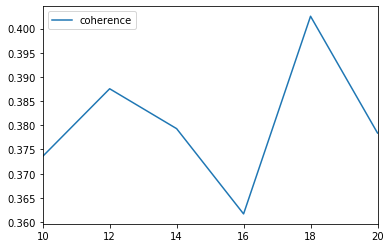

```python
model_measures.plot(y='coherence')
```

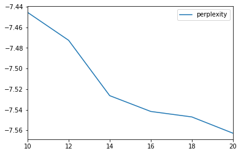

```python
model_measures.plot(y='perplexity')
```

```python
# 18 topics seems like a good candidate
# We'll tune once more for n_topics = [17,18,19] and
# n_passes = [10,25,50] and pick the best
coherences = pd.DataFrame(index=[17,18,19], columns=[10,25,50])
perplexities = pd.DataFrame(index=[17,18,19], columns=[10,25,50])
coherences.loc[18,25] = model_measures.loc[18,'coherence']
perplexities.loc[18,25] = model_measures.loc[18, 'perplexity']
```

```python
# %%time
# #Takes while -- Uncomment to run yourself
# #Pickled result included
#
# for n_topics in [17,18,19]:
#     for n_passes in [10,25,50]:
#         if (n_topics, n_passes) == (18,25):
#             continue
#         print(n_topics, n_passes)
#         lda_model = LdaModel(corpus=corpus,
#                     id2word=tridict,
#                     num_topics=n_topics,
#                     random_state=22,
#                     update_every=1,
#                     passes=n_passes,
#                     alpha='auto',
#                     per_word_topics=True)
#         lda_model.save("models/lda_" + str(n_topics) + "topics_" + str(n_passes) + "passes")
#         coherences.loc[n_topics, n_passes] = CoherenceModel(model=lda_model,
#                                           texts=ndf.trigrammed_overview,
#                                           dictionary=tridict,
#                                           coherence='c_v').get_coherence()
#         perplexities.loc[n_topics, n_passes] = lda_model.log_perplexity(corpus)
# coherences.to_pickle("pickle/coherences.pkl")
# perplexities.to_pickle("pickle/perplexities.pkl")
```

```python
coherences = pd.read_pickle("pickle/coherences.pkl")
perplexities = pd.read_pickle("pickle/perplexities.pkl")
print(coherences)
print(perplexities)
```

```
          10        25        50
17  0.375952  0.380919  0.383373
18   0.38459  0.402551   0.39848
19  0.372635  0.384801  0.388797
         10       25       50
17 -7.58085 -7.54849  -7.5378
18 -7.57841 -7.54702 -7.53651
19 -7.59284 -7.55863 -7.54652
```

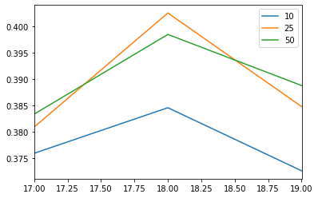

```python
coherences.plot()
```

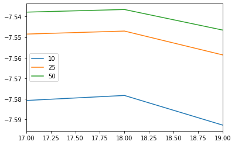

```python
perplexities.plot()
```

18 topics with 25 passes seems to have the best tradeoff of coherence vs. perplexity so that will be our final model.

###### Go to top

## 4.0 Model Interpretation

We've got a model, hurray! Let's see if we can make sense of the topics it came up with.

```python
import pyLDAvis
final_model = LdaModel.load("models/lda_18")
```

```python
# %%time
# #Takes while -- Uncomment to run yourself
# #Pickled result included
#
# LDAvis_prepared = pyLDAvis.gensim.prepare(final_model, corpus, tridict)
# pickle.dump(LDAvis_prepared, open('pickle/ldavis_prepared.pkl', 'wb'))
```

```python
LDAvis_prepared = pickle.load(open("pickle/ldavis_prepared.pkl", 'rb'))
```

```python
# Bottom right corner seems to be related to education and real estate.
# Upper right hand is related to apps or search.
# Left side is more analytics, services, and security oriented.

pyLDAvis.enable_notebook()
pyLDAvis.display(LDAvis_prepared)
```

[interactive chart not shown]

```python
pprint(final_model.print_topics(num_words=15))
```

```
[(0,
  '0.031*"online" + 0.024*"system" + 0.015*"event" + 0.014*"game" + '
  '0.013*"use" + 0.012*"base" + 0.012*"create" + 0.011*"tool" + 0.010*"travel" '
  '+ 0.010*"allow" + 0.009*"presentation" + 0.008*"website" + 0.008*"offer" + '
  '0.008*"inventory" + 0.007*"include"'),
 (1,
  '0.036*"marketing" + 0.024*"platform" + 0.019*"customer" + 0.016*"brand" + '
  '0.016*"content" + 0.014*"sale" + 0.012*"social" + 0.012*"online" + '
  '0.012*"mobile" + 0.011*"lead" + 0.010*"social_medium" + 0.010*"consumer" + '
  '0.009*"help" + 0.009*"tool" + 0.009*"include"'),
 (2,
  '0.030*"process" + 0.024*"solution" + 0.014*"provide" + 0.011*"improve" + '
  '0.010*"industry" + 0.009*"sap" + 0.009*"training" + 0.008*"document" + '
  '0.008*"organization" + 0.008*"accounting" + 0.008*"operation" + '
  '0.007*"asset" + 0.007*"help" + 0.007*"information" + 0.007*"investment"'),
 (3,
  '0.027*"datum" + 0.014*"solution" + 0.014*"provide" + 0.013*"performance" + '
  '0.012*"information" + 0.011*"analysis" + 0.009*"use" + 0.009*"platform" + '
  '0.008*"application" + 0.008*"risk" + 0.008*"base" + 0.008*"real_time" + '
  '0.008*"analytic" + 0.008*"enable" + 0.008*"intelligence"'),
 (4,
  '0.049*"script" + 0.032*"study" + 0.024*"city" + 0.020*"visualization" + '
  '0.020*"funding" + 0.017*"o" + 0.015*"site" + 0.014*"mashup" + 0.013*"crowd" '
  '+ 0.013*"compare" + 0.012*"clone" + 0.012*"brokerage" + 0.012*"webcast" + '
  '0.012*"sphere" + 0.011*"webinar"'),
 (5,
  '0.023*"app" + 0.023*"cloud" + 0.019*"use" + 0.017*"application" + '
  '0.017*"user" + 0.010*"content" + 0.009*"site" + 0.009*"create" + '
  '0.008*"browser" + 0.008*"website" + 0.007*"new" + 0.007*"desktop" + '
  '0.007*"add" + 0.007*"simple" + 0.006*"internet"'),
 (6,
  '0.024*"solution" + 0.015*"security" + 0.015*"technology" + 0.015*"testing" '
  '+ 0.013*"service" + 0.012*"automation" + 0.012*"test" + 0.010*"system" + '
  '0.010*"include" + 0.010*"product" + 0.010*"network" + 0.010*"provide" + '
  '0.008*"industry" + 0.007*"quality" + 0.006*"process"'),
 (7,
  '0.019*"information" + 0.017*"people" + 0.017*"social" + 0.016*"share" + '
  '0.014*"community" + 0.014*"create" + 0.013*"user" + 0.011*"music" + '
  '0.010*"online" + 0.010*"communication" + 0.009*"help" + '
  '0.009*"social_network" + 0.009*"group" + 0.008*"use" + 0.008*"find"'),
```

[output cut: 35 more lines]

```
 (15,
  '0.045*"project" + 0.020*"collaboration" + 0.020*"application" + '
  '0.019*"tool" + 0.018*"open_source" + 0.016*"use" + 0.015*"document" + '
  '0.015*"base" + 0.015*"online" + 0.014*"system" + 0.012*"team" + '
  '0.012*"platform" + 0.011*"task" + 0.011*"build" + 0.010*"developer"'),
 (16,
  '0.047*"design" + 0.036*"application" + 0.033*"service" + 0.020*"website" + '
  '0.018*"solution" + 0.017*"mobile" + 0.016*"provide" + 0.014*"base" + '
  '0.014*"mobile_application" + 0.014*"custom" + 0.013*"client" + '
  '0.012*"india" + 0.011*"develop" + 0.010*"developer" + 0.010*"specialize"'),
 (17,
  '0.027*"email" + 0.021*"mobile" + 0.021*"user" + 0.019*"security" + '
  '0.017*"access" + 0.016*"computer" + 0.013*"secure" + 0.012*"device" + '
  '0.011*"provide" + 0.011*"datum" + 0.011*"file" + 0.010*"network" + '
  '0.010*"control" + 0.009*"solution" + 0.008*"pc"')]
```

```python
ndf.head()
```

|  | normalized_name | overview | tag_list | funding_total_usd | processed_overview | preprocessed_overview | bigrammed_overview | trigrammed_overview |
| --- | --- | --- | --- | --- | --- | --- | --- | --- |
| 60 | oms safeharbor | OMS SafeHarbor provides software and services ... | software-distribution, electronic-software-del... | 0.0 | [provide, service, enable, electronic, deliver... | [provide, service, enable, electronic, deliver... | [provide, service, enable, electronic, deliver... | [provide, service, enable, electronic, deliver... |
| 65 | datapro services internationalltd | Datapro Services International Co, Ltd based i... | rss, bangkok, thailand, magazine | 0.0 | [datapro, international, co, ltd, base, bangko... | [datapro, international, co, ltd, base, bangko... | [datapro, international, co, ltd, base, bangko... | [datapro, international, co, ltd, base, bangko... |
| 121 | epianalytics | EpiAnalytics provides easy to use text and sen... | twitter-sentiment-analysis, nlp, epianalytics,... | 0.0 | [epianalytic, provide, easy, use, text, sentim... | [epianalytic, provide, easy, use, text, sentim... | [epianalytic, provide, easy_use, text, sentime... | [epianalytic, provide, easy_use, text, sentime... |
| 122 | amax global services | AMAX Global Services is a software developmen... |  | 45000.0 | [amax, global, offshore, outsourcing, partner,... | [amax, global, offshore, outsourcing, partner,... | [amax, global, offshore_outsourcing, partner, ... | [amax, global, offshore_outsourcing, partner, ... |
| 130 | tingz | Tingz is changing the way people experience th... | techcrunch50, tc50, consumer, software, widgets | 280000.0 | [change, way, people, experience, internet, to... | [change, way, people, experience, internet, to... | [change_way, people, experience, internet, too... | [change_way_people, experience, internet, tool... |

```python
# %%time
# #Takes while -- Uncomment to run yourself
# #Pickled result included
#
# final_df = ndf.copy()
# company_topic = []
# probability = []
# for topics in final_model[corpus]:
#     associations = topics[0]
#     topic, prob = sorted(associations,key = lambda x: x[1], reverse=True)[0]
#     company_topic.append(topic)
#     probability.append(prob)
# final_df['company_topic'] = company_topic
# final_df['probability'] = probability
# final_df.to_pickle("pickle/final_df.pkl")
```

```python
# Trying to get a better idea of what these topics mean, let's take a sample of
# company overviews that were classified within each.
final_df = pd.read_pickle("pickle/final_df.pkl")
final_df.head()
```

|  | normalized_name | overview | tag_list | funding_total_usd | processed_overview | preprocessed_overview | bigrammed_overview | trigrammed_overview | company_topic | probability |
| --- | --- | --- | --- | --- | --- | --- | --- | --- | --- | --- |
| 60 | oms safeharbor | OMS SafeHarbor provides software and services ... | software-distribution, electronic-software-del... | 0.0 | [provide, service, enable, electronic, deliver... | [provide, service, enable, electronic, deliver... | [provide, service, enable, electronic, deliver... | [provide, service, enable, electronic, deliver... | 8 | 0.440778 |
| 65 | datapro services internationalltd | Datapro Services International Co, Ltd based i... | rss, bangkok, thailand, magazine | 0.0 | [datapro, international, co, ltd, base, bangko... | [datapro, international, co, ltd, base, bangko... | [datapro, international, co, ltd, base, bangko... | [datapro, international, co, ltd, base, bangko... | 0 | 0.594554 |
| 121 | epianalytics | EpiAnalytics provides easy to use text and sen... | twitter-sentiment-analysis, nlp, epianalytics,... | 0.0 | [epianalytic, provide, easy, use, text, sentim... | [epianalytic, provide, easy, use, text, sentim... | [epianalytic, provide, easy_use, text, sentime... | [epianalytic, provide, easy_use, text, sentime... | 14 | 0.277081 |
| 122 | amax global services | AMAX Global Services is a software developmen... |  | 45000.0 | [amax, global, offshore, outsourcing, partner,... | [amax, global, offshore, outsourcing, partner,... | [amax, global, offshore_outsourcing, partner, ... | [amax, global, offshore_outsourcing, partner, ... | 14 | 0.406279 |
| 130 | tingz | Tingz is changing the way people experience th... | techcrunch50, tc50, consumer, software, widgets | 280000.0 | [change, way, people, experience, internet, to... | [change, way, people, experience, internet, to... | [change_way, people, experience, internet, too... | [change_way_people, experience, internet, tool... | 13 | 0.385782 |

```python
# Looks like some overviews with just spaces slipped through
topic_representatives = final_df.sort_values(['company_topic','probability'], ascending=False).groupby('company_topic').head(2)[['normalized_name','overview','company_topic','probability']]
for i in range(36):
    if i%2 == 0:
        print('\n')
        print("TOPIC MODEL {}".format(17-i//2))
    print(final_model.print_topics(num_words=5)[17-i//2])
    pprint(topic_representatives.iloc[i].values)
```

```
TOPIC MODEL 17
(17, '0.027*"email" + 0.021*"mobile" + 0.021*"user" + 0.019*"security" + 0.017*"access"')
array(['systools software',
       'SysTools Group is a vast provider of system utilities & tools to help you run your PC smoothly and with ease. SysTools Group has been helping businesses by improving their communication and mailbox structure or by providing specialized tools and services for the need of Lotus Notes and Outlo…
       17, 0.9452869892120361], dtype=object)
(17, '0.027*"email" + 0.021*"mobile" + 0.021*"user" + 0.019*"security" + 0.017*"access"')
array(['sms messaging',
       'Useful and cost efficient pocket PC to mobile text messaging software provides an option to send multiple sms to a single or group of users pocket, pc, text, message, software, send, unlimited, sms, gsm, cdma, mobile',
       17, 0.917130172252655], dtype=object)


TOPIC MODEL 16
(16, '0.047*"design" + 0.036*"application" + 0.033*"service" + 0.020*"website" + 0.018*"solution"')
array(['xminds',
       'Xminds is an 8 year old Software development and testing Services Company located in Kerala, India and currently having offices in  Singapore and Australia.Providing services to more than 85 startups, Xminds has been excellent development partner for business in social media and mobile appli…
       16, 0.9509925246238708], dtype=object)
(16, '0.047*"design" + 0.036*"application" + 0.033*"service" + 0.020*"website" + 0.018*"solution"')
array(['webexpressindia',
       'Webexpressindia are a Website Design Company based at Bangalore, Karnataka offering high quality Website Designing, Website development, web promotion , Ecommerce Solutions & Software Development Services,website design and development,Website designing,Website design india,Website design se…
       16, 0.9463138580322266], dtype=object)


TOPIC MODEL 15
(15, '0.045*"project" + 0.020*"collaboration" + 0.020*"application" + 0.019*"tool" + 0.018*"open_source"')
array(['officetime',
       "OfficeTime is a time tracking software for Mac, Windows, iPhone and iPad. OfficeTime is an intuitive time tracker. Where other time keepers are clumsy or oversimplified, OfficeTime balances features and ease of use, allowing you to easily track exactly what you do each day. OfficeTime record…
       15, 0.9520341157913208], dtype=object)
(15, '0.045*"project" + 0.020*"collaboration" + 0.020*"application" + 0.019*"tool" + 0.018*"open_source"')
array(['fanurio time tracking',
       'Fanurio Time Tracking is a private held company that develops Fanurio, a time tracking and billing application for freelancers. Fanurio is specially optimized to manage contracted work and billing for freelancers. Unlike most time tracking and billing applications that are built for both fre…
       15, 0.9477123022079468], dtype=object)


TOPIC MODEL 14
(14, '0.032*"solution" + 0.023*"customer" + 0.022*"service" + 0.018*"client" + 0.017*"technology"')
array(['xeux innovations',
       'Xeux Innovations is a company dedicated to offer technology products, good service, outsource web development and the best attention. Our goal is provide the solution that you need in the time that you expect and with the best quality in the market.We are located in Panama and all our team s…
       14, 0.9691384434700012], dtype=object)
(14, '0.032*"solution" + 0.023*"customer" + 0.022*"service" + 0.018*"client" + 0.017*"technology"')
array(['lampglow solutions',
```

[output cut: 141 more lines]

```
(1, '0.036*"marketing" + 0.024*"platform" + 0.019*"customer" + 0.016*"brand" + 0.016*"content"')
array(['manticore technology',
       'Manticore Technology  is a SaaS Marketing Automation solution provider that enables marketers to move sales prospects through the pipeline  through lead nurturing, lead management, lead scoring, while feeding their sales team  insight about the interests of each lead. Manticore Technology ha…
       1, 0.8452781438827515], dtype=object)


TOPIC MODEL 0
(0, '0.031*"online" + 0.024*"system" + 0.015*"event" + 0.014*"game" + 0.013*"use"')
array(['brightblue',
       'B2B SaaS based service that allows sales staff from commercial printers or print managers to produce detailed automated quotations.System works out the optimal lowest cost manufacturing approach based on each printers specific equipment, costs and preferences. This is then used to create a s…
       0, 0.9439855813980103], dtype=object)
(0, '0.031*"online" + 0.024*"system" + 0.015*"event" + 0.014*"game" + 0.013*"use"')
array(['thundertix',
       "ThunderTix is an event ticketing software and box office management system. ThunderTix is offered as an ongoing software as a service to venues who use it to sell tickets for their events.What makes ThunderTix unique in the industry is that NO per ticket fees or order  fees are added to any …
       0, 0.9039346575737], dtype=object)
```

```python
#My guess at what the machines were thinking
topic_names = {0:'eCommerce',
                1:'Marketing Analytics',
                2:'Platform as a Service',
                3:'Data Consulting',
                4:'Miscellaneous',
                5:'App Centric',
                6:'Infrastructure Technology',
                7:'Social Network',
                8:'Domestic Tech Consulting/Outsourcing',
                9:'Audio and Voice',
                10:'Recruiting',
                11:'High Performance Computing',
                12:'Miscellaneous',
                13:'Surveillance and Productivity',
                14:'Int\'l Tech Consulting/Outsourcing',
                15:'Time Tracking',
                16:'Design Services',
                17:'Messaging Utilities'
}
```